# ConsensusPeaks

Helen Zhu

# Introduction

A common step in the bioinformatic analysis of epigenetic pulldown experiments such as ChIP-seq, ATAC-seq, MeRIP-seq, CLIP-seq and other methods is to call peaks across biological replicates. In such studies, it is often desirable to identify a set of common peaks between replicates, count reads and conduct differential analysis. It is easy to identify common peaks with few replicates by simply taking the union of the set of peak regions. However, as datasets grow, the length of peak unions also grow, spanning the finite space defined by the genome or transcriptome. Additionally, epitranscriptomic pulldown experiments are growing in popularity. While peak callers for the transcriptome (e.g. exomePeak, MeTPeak) have been created, there is no available tool to identify overlapping peaks that span multiple exons. ConsensusPeaks is a tool that implements several models described in the literature to identify a consensus set of regions for RNA pulldown experiments.

# Methods

### The Union Method

The most commonly used method is taking the union of the regions identified across multiple samples.

### Corces et al., 2018

In [Corces et al., 2018](https://science.sciencemag.org/content/362/6413/eaav1898.abstract), a 'daisy chain' approach was implemented to merge peaks called on ATAC-seq data. In a set of overlapping peaks, the peak with the lowest p-value is used as the representative peak.

### Dirichlet Process Gaussian Mixture Models

In [unpublished work], a Gaussian mixture model (GMM) with a Dirichlet Process prior is fit on the pile-up of bed files. We are using the implementation of the GMM from the R package [DirichletProcess](https://cran.r-project.org/web/packages/dirichletprocess/index.html).

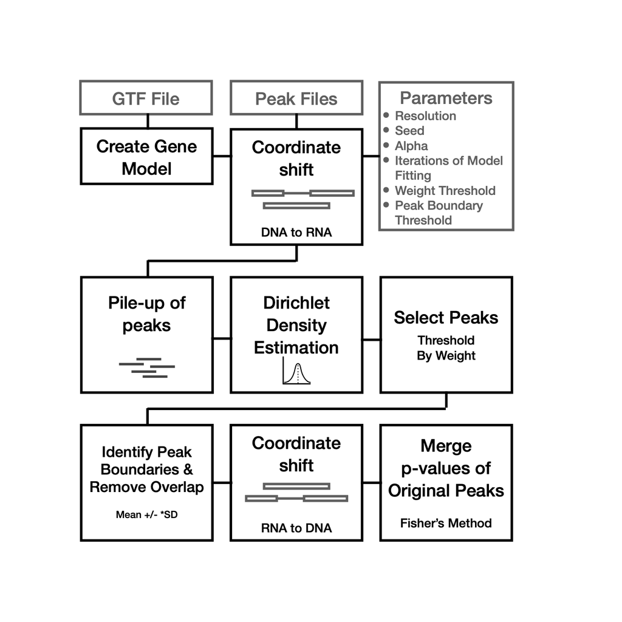

Dirichlet Process Gaussian Mixture Models

# Example

## Simulating Peaks from Gaussians

To start, we wrote a function called `simulate.gaussian.peaks` to simulate peaks using Gaussian distributions on RNA transcripts. To simulate peaks, the user is required to provide the following for each Gaussian:

1. `MU` is a vector of means given in transcriptomic coordinates.
2. `SD` is a vector of standard deviations.
3. `EXTEND.WIDTH` is the desired length of peaks in bps.
4. `NSAMPLES` is the number of samples where each sample generates each peak (so in other words, the number of peaks).

Using a GTF file provided by the user, the user needs to indicate:

5. `GTF` is the path to the GTF (Yes, we made a toy one that is included in the package, feel free to borrow it!)
6. `GENE` is the gene_id of the gene on which to simulate peaks. This gene must be found in the GTF file.

For reproducibility, we also included a seed.

7. `SEED` for reproducibility.

The output of this function is a BED12 file (read [here](https://genome.ucsc.edu/FAQ/FAQformat.html#format1) for details) with an extra column `sample` indicating sample id's of biological replicates. This format fits nicely with downstream functions as a `PEAKS` data frame.

```r
# Loading a toy GTF File
data.path = system.file("extdata", package = "ConsensusPeaks")
gtf = paste0(data.path, "/test.gtf")

# Simulating Peaks
ensgxx = simulate.gaussian.peaks(
  MU = c(100, 150),
  SD = c(10, 20),
  EXTEND.WIDTH = c(50, 25),
  NSAMPLES = c(10, 30),
  GENE = "ENSGXX",
  GTF = gtf,
  SEED = 123)

head(ensgxx)
```

```
##    chr start end   name score strand thickStart thickEnd itemRgb
## 1 chr1   368 716 ENSGXX     0      +        368      716       0
## 2 chr1   372 720 ENSGXX     0      +        372      720       0
##   blockCount blockSizes blockStarts     sample
## 1          2     32,16,      0,332, Sample.1.1
## 2          2     28,20,      0,328, Sample.1.2
##  [ reached getOption("max.print") -- omitted 4 rows ]
```

## Visualizing Peaks across a Gene

If you are anything like us, you would want to know what this looks like. Thus, we wrote a function to visualize peaks in a genomic coordinate system.

1. `GENE` is the gene_id.
2. `PEAKS` is the set of peaks called in a BED12 format with an extra column indicating sample id.
3. `GTF` is the path to the GTF file.
4. `OUTPUTDIR` is the output directory.
5. `OUTPUT.TAG` is the character string attached to the output file.
6. `PLOT` is a logical indicator which if `TRUE` will create a plot in PDF format in the output directory. Otherwise, if `FALSE`, it will only return the ggplot object.

```r
# Loading Peaks
peaks.file = paste0(data.path, "/peaks.bed")

peaks = read.table(
  peaks.file,
  header = F,
  sep = "\t",
  stringsAsFactors = F)

colnames(peaks) = c("chr", "start", "end", "name", "score", "strand", "thickStart", "thickEnd",
                    "itemRGB", "blockCount", "blockSizes", "blockStarts", "sample")

# Plotting Peaks
p = plot.gene.peaks(
  GENE = "ENSGXX",
  PEAKS = peaks,
  GTF = gtf,
  OUTPUTDIR = ".",
  OUTPUT.TAG = "",
  PLOT = F
)
```

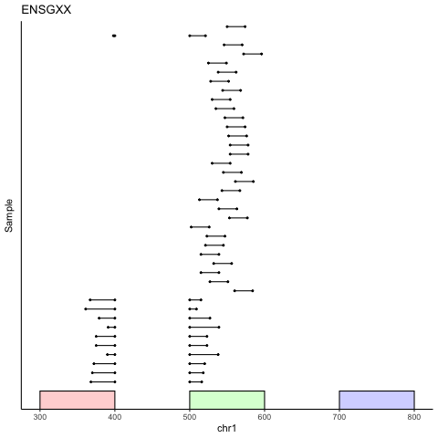

Peaks in a genomic coordinate system

## Identify Consensus Peaks using a GMM with a Dirichlet Process Prior

We wrote a function to fit a GMM with a Dirichlet Process prior on the pileup of peaks. The following parameters are required:

1. `GENES` A character vector of gene_id's to be tested.
2. `PEAKS` A data frame containing the following columns, and potentially extras, usually found in a BED12 file, base 0 system. An addition column `sample` is required to indicate sample id of the biological replicates.
- `chr` chromosomes, character, same format as those identified in GTF file
- `start` starting position of the peak, integer. base 0
- `end` end position of the peak, integer, base 0
- `name` gene id, character
- `score` p-value associated with the peak
- `strand` strand of the gene, only +, -, * are accepted
- `blockCount` number of segments in the peak, integer
- `blockSizes` size of segments in the peak, BED12 notation, comma-separated
- `blockStarts` starting positions of segments, BED12 notation, comma-separated
- `sample` sample_id of samples, character
3. `RNA.OR.DNA` One of 'rna' or 'dna' indicating whether peaks are identified on the transcriptome or genome.
4. `METHOD` One 'dpc', 'union', 'corces' indicating the method used to merge peaks.
5. `GTF` The path to a GTF file, character string.
6. `DP.RESOLUTION` If the METHOD is 'dpc', specify the resolution of the provided PEAKS data.frame. This usually corresponds to the bin width chosen when the peaks are called, a positive integer.
7. `DP.ITERATIONS` If the METHOD is 'dpc', specify the number of iterations used to fit the GMM, a positive integer.
8. `DP.WEIGHT.THRESHOLD` If the METHOD is 'dpc', specify the minimum weight used to threshold the Gaussians. This value is required to be numeric and between 0 and 1.
9. `DP.N.SD` If the METHOD is 'dpc', specify the standard deviation of the Gaussians required to identify peak boundaries, numeric value, above 0.
10. `DP.ALPHA.PRIORS` If the METHOD is 'dpc', specify the priors (alpha, beta) for the Gamma distribution from which the weight concentration prior is drawn, numeric vector of length 2
11. `DP.SEED` A seed for reproducibility, integer above 0.
12. `PLOT.MERGED.PEAKS` Either a logical value (TRUE or FALSE) indicating all or none of the merged peaks should be plotted. Otherwise, a character vector of genes whose merged peaks should be plotted.
13. `OUTPUT.TAG` A character string added to the names of any output files.
14. `OUTPUTDIR` Output directory. If the directory does not exist, ConsensusPeaks will attempt to create the directory.
15. `WRITE.OUTPUT` A logical value indicating whether the output table should be written. Otherwise, it is returned.

```r
results = ConsensusPeaks(
 GENES = c("ENSGXX", "ENSGYY"),
 PEAKS = peaks,
 RNA.OR.DNA = "rna",
 METHOD = "dpc",
 GTF = gtf,
 DP.RESOLUTION = 10,
 DP.ITERATIONS = 1000,
 DP.WEIGHT.THRESHOLD = 0.1,
 DP.N.SD = 1.5,
 DP.ALPHA.PRIORS = c(0.5,5),
 DP.SEED = 123,
 PLOT.MERGED.PEAKS = F,
 OUTPUT.TAG = "TEST",
 OUTPUTDIR = ".",
 WRITE.OUTPUT = F
)
```

```
## [1] "50 %"
## [1] "100 %"
```

```r
head(results[,1:13])
```

```
##    chr start end   name score strand thickStart thickEnd itemRgb
## 1 chr1   504 571 ENSGXX     0      +        504      571       0
## 2 chr1   359 504 ENSGXX     0      +        359      504       0
##   blockCount blockSizes blockStarts Sample.1.1
## 1          1        67,          0,      2e-16
## 2          2      41,5,      0,140,      2e-16
##  [ reached getOption("max.print") -- omitted 1 row ]
```

Below are the results from the ENSGXX gene using the peaks we simulated earlier. On the left, the plot shows a histogram of counts sampled at `DP.RESOLUTION` base pairs in grey. This is the distribution of data observed by GMM. The black line indicates the fitted GMM. The colored lines show the individual Gaussians fitted, scaled by weight. The colored rectangles at the bottom show the retrieved peaks. On the right, the plot shows a bp resolution coverage of pileup of peaks in grey. This plot is used to diagnose issues with sampling at an unsuitable resolution.

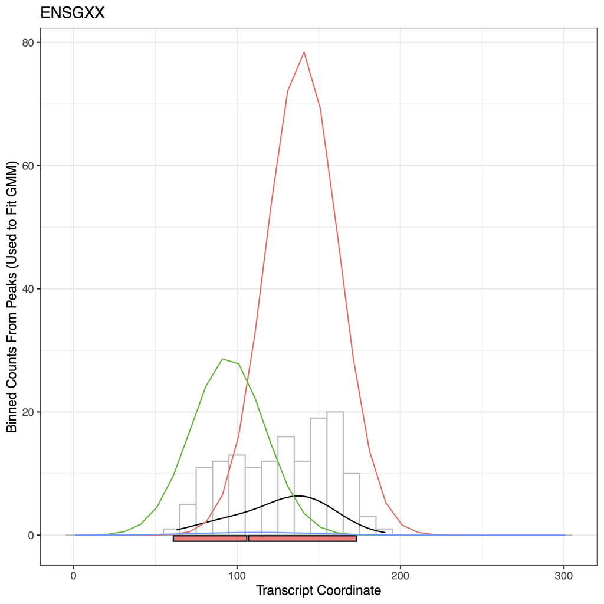

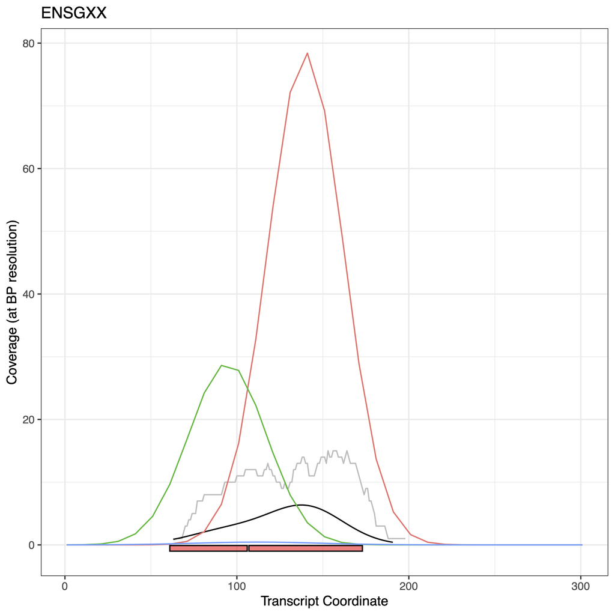

## Parameter Tuning for the GMM Model

### Alpha Priors

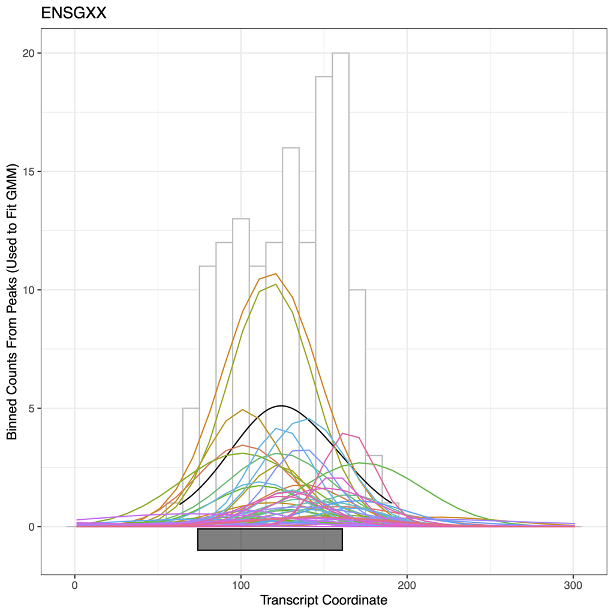

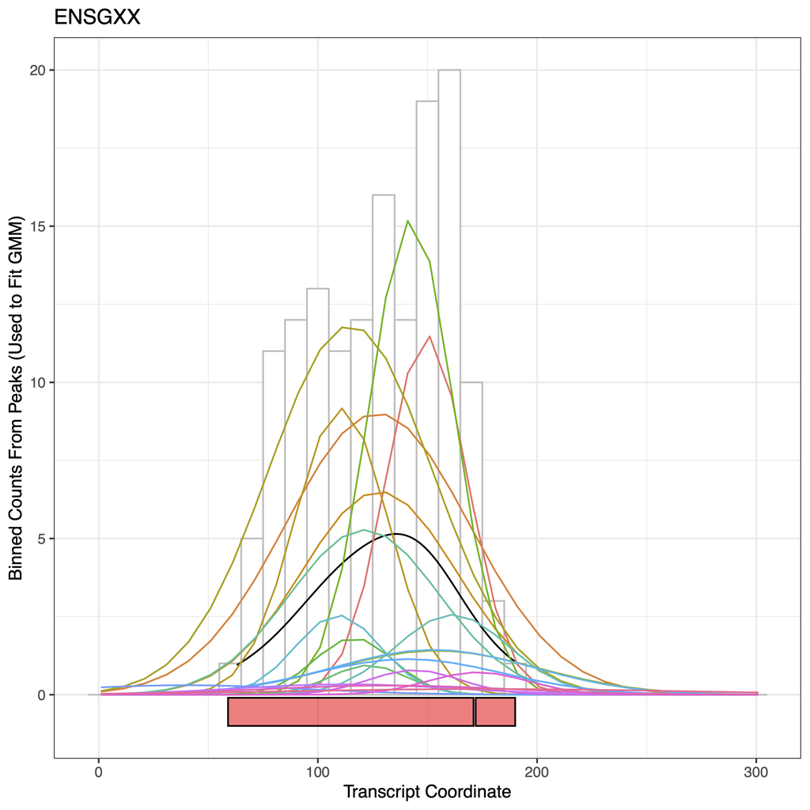

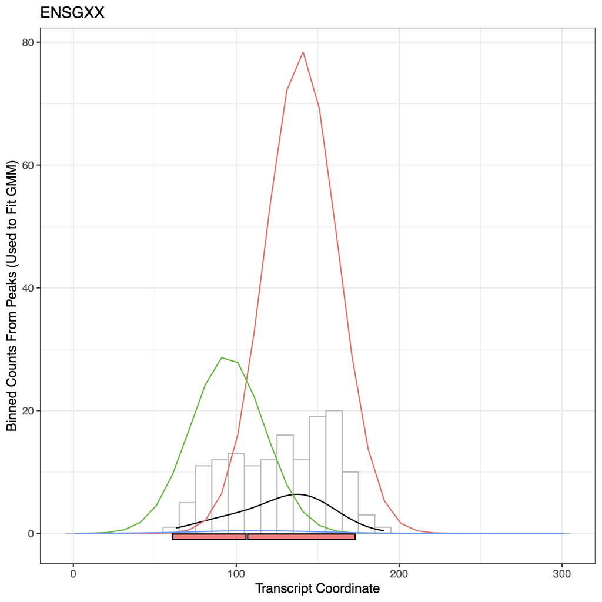

## P values

Currently, p values per sample in the output file results from merging p values of peaks that overlap with the resulting peak using Fisher's Method.